# STAT364 Data Science Inference, Predictor, and Explanation Homework 02

Kira Novitchkova-Burbank

# Chapter 3 Problem 1:

### For the prostate data, fit a model with lpsa as the response and the other variables as predictors:

### (a) Compute 90 and 95% CIs for the parameter associated with age. Using just these intervals, what could we have deduced about the p-value for age in the regression summary?

Your code:

```r
library(faraway)

data(prostate, package = "faraway")
summary(prostate)
```

```
##      lcavol           lweight           age             lbph
##  Min.   :-1.3471   Min.   :2.375   Min.   :41.00   Min.   :-1.3863
##  1st Qu.: 0.5128   1st Qu.:3.376   1st Qu.:60.00   1st Qu.:-1.3863
##  Median : 1.4469   Median :3.623   Median :65.00   Median : 0.3001
##  Mean   : 1.3500   Mean   :3.653   Mean   :63.87   Mean   : 0.1004
##  3rd Qu.: 2.1270   3rd Qu.:3.878   3rd Qu.:68.00   3rd Qu.: 1.5581
##  Max.   : 3.8210   Max.   :6.108   Max.   :79.00   Max.   : 2.3263
##       svi              lcp             gleason          pgg45
##  Min.   :0.0000   Min.   :-1.3863   Min.   :6.000   Min.   :  0.00
##  1st Qu.:0.0000   1st Qu.:-1.3863   1st Qu.:6.000   1st Qu.:  0.00
##  Median :0.0000   Median :-0.7985   Median :7.000   Median : 15.00
##  Mean   :0.2165   Mean   :-0.1794   Mean   :6.753   Mean   : 24.38
##  3rd Qu.:0.0000   3rd Qu.: 1.1786   3rd Qu.:7.000   3rd Qu.: 40.00
##  Max.   :1.0000   Max.   : 2.9042   Max.   :9.000   Max.   :100.00
##       lpsa
##  Min.   :-0.4308
##  1st Qu.: 1.7317
##  Median : 2.5915
##  Mean   : 2.4784
##  3rd Qu.: 3.0564
##  Max.   : 5.5829
```

Your code:

```r
lmod <- lm(lpsa ~ lcavol + lweight + age + lbph + svi + lcp + gleason + pgg45, data = prostate)
lmod
```

```
##
## Call:
## lm(formula = lpsa ~ lcavol + lweight + age + lbph + svi + lcp +
##     gleason + pgg45, data = prostate)
##
## Coefficients:
## (Intercept)       lcavol      lweight          age         lbph          svi
##    0.669337     0.587022     0.454467    -0.019637     0.107054     0.766157
##         lcp      gleason        pgg45
##   -0.105474     0.045142     0.004525
```

```r
#CI stands for confidence interval
CI90 <- confint(lmod, level = 0.90)
print("CI90:")
```

```
## [1] "CI90:"
```

```r
print(CI90)
```

```
##                      5 %         95 %
## (Intercept) -1.485718237  2.824391633
## lcavol       0.440867156  0.733176497
## lweight      0.171846568  0.737088281
## age         -0.038210200 -0.001064151
## lbph         0.009890745  0.204217317
## svi          0.360029029  1.172285623
## lcp         -0.256770899  0.045822373
## gleason     -0.216620186  0.306903382
## pgg45       -0.002824333  0.011874796
```

```r
CI95 <- confint(lmod, level = 0.95)
print("CI95:")
```

```
## [1] "CI95:"
```

```r
print(CI95)
```

```
##                    2.5 %      97.5 %
## (Intercept) -1.906960983 3.245634379
## lcavol       0.412298699 0.761744954
## lweight      0.116603435 0.792331414
## age         -0.041840618 0.002566267
## lbph        -0.009101499 0.223209561
## svi          0.280644232 1.251670420
## lcp         -0.286344443 0.075395916
## gleason     -0.267786053 0.358069248
## pgg45       -0.004260932 0.013311395
```

Your answer: The 90% confidence interval for age is (-0.038210200, -0.001064151). The 95% confidence interval for age is (-0.041840618, 0.002566267). The narrower the interval the smaller the p-value. The 90% confidence interval is narrower, so the p-value for age in CI 90% is smaller.

**Put your answer, explanation, findings here**

### (b) Compute and display a 95% joint confidence region for the parameters associated with age and lbph. Plot the origin on this display. The location of the origin on the display tells us the outcome of a certain hypothesis test. State that test and its outcome.

Your code:

```r
#first install package
#install.packages("ellipse")
library(ellipse)
```

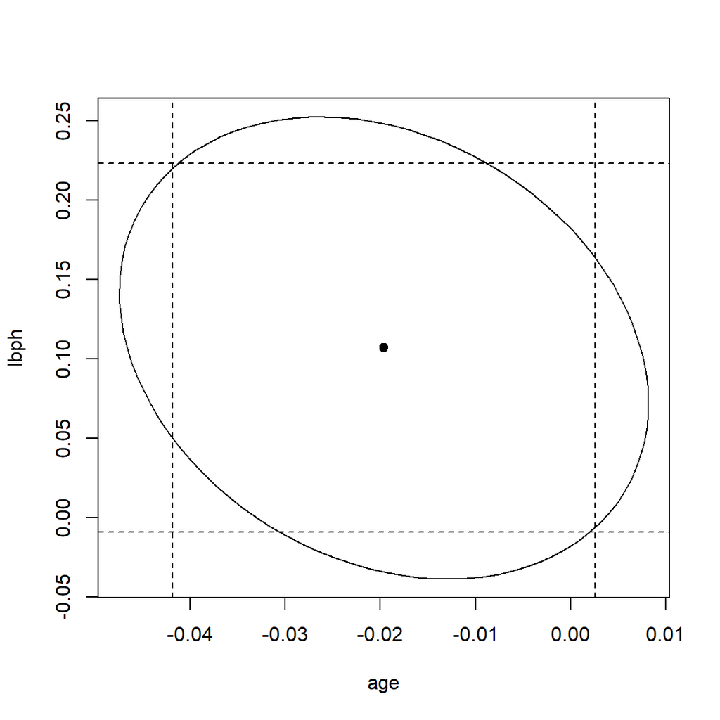

```r
#ellipse
plot(ellipse(lmod, c("age", "lbph")), type="l")
#origin
points(coef(lmod) ["age"], coef(lmod) ["lbph"], pch=19)

#intervals
abline(v=CI95["age",], lty=2)
abline(h=CI95["lbph",], lty=2)
```

Your answer: It looks like the origin (0,0) is inside both intervals and is inside the ellipse, as well. That means that both the joint hypothesis and the single hypotheses are not rejected.

**Put your answer, explanation, findings here**

### (d) Remove all the predictors that are not significant at the 5% level. Test this model against the original model. Which model is preferred?

Your code:

```r
summary(lmod)
```

```
##
## Call:
## lm(formula = lpsa ~ lcavol + lweight + age + lbph + svi + lcp +
##     gleason + pgg45, data = prostate)
##
## Residuals:
##     Min      1Q  Median      3Q     Max
## -1.7331 -0.3713 -0.0170  0.4141  1.6381
##
## Coefficients:
##              Estimate Std. Error t value Pr(>|t|)
## (Intercept)  0.669337   1.296387   0.516  0.60693
## lcavol       0.587022   0.087920   6.677 2.11e-09 ***
## lweight      0.454467   0.170012   2.673  0.00896 **
## age         -0.019637   0.011173  -1.758  0.08229 .
## lbph         0.107054   0.058449   1.832  0.07040 .
## svi          0.766157   0.244309   3.136  0.00233 **
## lcp         -0.105474   0.091013  -1.159  0.24964
## gleason      0.045142   0.157465   0.287  0.77503
## pgg45        0.004525   0.004421   1.024  0.30886
## ---
## Signif. codes:  0 '***' 0.001 '**' 0.01 '*' 0.05 '.' 0.1 ' ' 1
##
## Residual standard error: 0.7084 on 88 degrees of freedom
## Multiple R-squared:  0.6548, Adjusted R-squared:  0.6234
## F-statistic: 20.86 on 8 and 88 DF,  p-value: < 2.2e-16
```

```r
#the not significant predictors at 5% are the predictors with the p values that are > 0.05 which are age, lbph, lcp, gleason, and pgg45
lmod_sp <- lm(lpsa ~ lcavol + lweight + svi, data = prostate) #sp stands for significant predictors
lmod_sp
```

```
##
## Call:
## lm(formula = lpsa ~ lcavol + lweight + svi, data = prostate)
##
## Coefficients:
## (Intercept)       lcavol      lweight          svi
##     -0.2681       0.5516       0.5085       0.6662
```

```r
anova(lmod_sp, lmod)
```

```
## Analysis of Variance Table
##
## Model 1: lpsa ~ lcavol + lweight + svi
## Model 2: lpsa ~ lcavol + lweight + age + lbph + svi + lcp + gleason +
##     pgg45
##   Res.Df    RSS Df Sum of Sq      F Pr(>F)
## 1     93 47.785
## 2     88 44.163  5    3.6218 1.4434 0.2167
```

Your answer: Since, the p-value is 0.2167 which is greater than 0.05, that means that we failed to reject the null hypothesis. That means that the reduced model is better than the full model.

**Put your answer, explanation, findings here**

# Chapter 3 Problem 2:

### Thirty samples of cheddar cheese were analyzed for their content of acetic acid, hydrogen sulfide and lactic acid. Each sample was tasted and scored by a panel of judges and the average taste score produced. Use the cheddar data to answer the following: (a) Fit a regression model with taste as the response and the three chemical contents as predictors. Identify the predictors that are statistically significant at the 5% level.

Your code:

```r
data("cheddar", package = "faraway")
summary(cheddar)
```

```
##      taste           Acetic           H2S             Lactic
##  Min.   : 0.70   Min.   :4.477   Min.   : 2.996   Min.   :0.860
##  1st Qu.:13.55   1st Qu.:5.237   1st Qu.: 3.978   1st Qu.:1.250
##  Median :20.95   Median :5.425   Median : 5.329   Median :1.450
##  Mean   :24.53   Mean   :5.498   Mean   : 5.942   Mean   :1.442
##  3rd Qu.:36.70   3rd Qu.:5.883   3rd Qu.: 7.575   3rd Qu.:1.667
##  Max.   :57.20   Max.   :6.458   Max.   :10.199   Max.   :2.010
```

```r
lmod <- lm(taste ~ Acetic + H2S + Lactic, data=cheddar)
summary(lmod)
```

```
##
## Call:
## lm(formula = taste ~ Acetic + H2S + Lactic, data = cheddar)
##
## Residuals:
##     Min      1Q  Median      3Q     Max
## -17.390  -6.612  -1.009   4.908  25.449
##
## Coefficients:
##             Estimate Std. Error t value Pr(>|t|)
## (Intercept) -28.8768    19.7354  -1.463  0.15540
## Acetic        0.3277     4.4598   0.073  0.94198
## H2S           3.9118     1.2484   3.133  0.00425 **
## Lactic       19.6705     8.6291   2.280  0.03108 *
## ---
## Signif. codes:  0 '***' 0.001 '**' 0.01 '*' 0.05 '.' 0.1 ' ' 1
##
## Residual standard error: 10.13 on 26 degrees of freedom
## Multiple R-squared:  0.6518, Adjusted R-squared:  0.6116
## F-statistic: 16.22 on 3 and 26 DF,  p-value: 3.81e-06
```

Your answer: The predictors that are significant at the the 5% level are H2S and Lactic.

**Put your answer, explanation, findings here**

### (b) Acetic and H2S are measured on a log scale. Fit a linear model where all three predictors are measured on their original scale. Identify the predictors that are statistically significant at the 5% level for this model.

Your code:

```r
lmod <- lm(taste ~ exp(Acetic) + exp(H2S) + Lactic, data=cheddar)
summary(lmod)
```

```
##
## Call:
## lm(formula = taste ~ exp(Acetic) + exp(H2S) + Lactic, data = cheddar)
##
## Residuals:
##     Min      1Q  Median      3Q     Max
## -16.209  -7.266  -1.651   7.385  26.335
##
## Coefficients:
##               Estimate Std. Error t value Pr(>|t|)
## (Intercept) -1.897e+01  1.127e+01  -1.684   0.1042
## exp(Acetic)  1.891e-02  1.562e-02   1.210   0.2371
## exp(H2S)     7.668e-04  4.188e-04   1.831   0.0786 .
## Lactic       2.501e+01  9.062e+00   2.760   0.0105 *
## ---
## Signif. codes:  0 '***' 0.001 '**' 0.01 '*' 0.05 '.' 0.1 ' ' 1
##
## Residual standard error: 11.19 on 26 degrees of freedom
## Multiple R-squared:  0.5754, Adjusted R-squared:  0.5264
## F-statistic: 11.75 on 3 and 26 DF,  p-value: 4.746e-05
```

Your answer: Only Lactic is statistically significant at the 5% level.

**Put your answer, explanation, findings here**

### (c) Can we use an F-test to compare these two models? Explain. Which model provides a better fit to the data? Explain your reasoning.

Your answer: These models are not nested, so an F-test cannot be used to compare these two models. I’m pretty sure that I should compare the R^2’s for these two models in order to understand which model provides a better fit to the data. For the first model the R^2 value is 0.6518, and the R^2 value for the second model is 0.5754. Since 0.6518 is closer to 1, that means that the first model is better.

**Put your answer, explanation, findings here**

### (d) If H2S is increased 0.01 for the model used in (a), what change in the taste would be expected?

Your code:

```r
summary(lmod)
```

```
##
## Call:
## lm(formula = taste ~ exp(Acetic) + exp(H2S) + Lactic, data = cheddar)
##
## Residuals:
##     Min      1Q  Median      3Q     Max
## -16.209  -7.266  -1.651   7.385  26.335
##
## Coefficients:
##               Estimate Std. Error t value Pr(>|t|)
## (Intercept) -1.897e+01  1.127e+01  -1.684   0.1042
## exp(Acetic)  1.891e-02  1.562e-02   1.210   0.2371
## exp(H2S)     7.668e-04  4.188e-04   1.831   0.0786 .
## Lactic       2.501e+01  9.062e+00   2.760   0.0105 *
## ---
## Signif. codes:  0 '***' 0.001 '**' 0.01 '*' 0.05 '.' 0.1 ' ' 1
##
## Residual standard error: 11.19 on 26 degrees of freedom
## Multiple R-squared:  0.5754, Adjusted R-squared:  0.5264
## F-statistic: 11.75 on 3 and 26 DF,  p-value: 4.746e-05
```

Your answer: If H2S is increased by 0.01 then that would mean that the beta hat for H2S would have to be multiplied by 0.01, and the answer to that would be the expected change in taste. 3.9118 * 0.01 = 0.039118. So, the expected change in taste would be 0.039118.

**Put your answer, explanation, findings here**

# Chapter 3 Problem 7:

### In the punting data, we find the average distance punted and hang times of 10 punts of an American football as related to various measures of leg strength for 13 volunteers. (a) Fit a regression model with Distance as the response and the right and left leg strengths and flexibilities as predictors. Which predictors are significant at the 5% level?

Your code:

```r
data("punting", package = "faraway")
summary(punting)
```

```
##     Distance          Hang            RStr            LStr
##  Min.   :104.9   Min.   :3.020   Min.   :110.0   Min.   :110.0
##  1st Qu.:140.2   1st Qu.:3.640   1st Qu.:130.0   1st Qu.:130.0
##  Median :150.2   Median :4.040   Median :150.0   Median :150.0
##  Mean   :148.2   Mean   :3.921   Mean   :147.7   Mean   :143.8
##  3rd Qu.:163.5   3rd Qu.:4.180   3rd Qu.:170.0   3rd Qu.:160.0
##  Max.   :192.0   Max.   :4.750   Max.   :180.0   Max.   :180.0
##      RFlex            LFlex             OStr
##  Min.   : 85.00   Min.   : 78.00   Min.   :130.2
##  1st Qu.: 90.00   1st Qu.: 86.00   1st Qu.:153.9
##  Median : 93.00   Median : 93.00   Median :197.1
##  Mean   : 95.69   Mean   : 91.23   Mean   :196.2
##  3rd Qu.:103.00   3rd Qu.: 94.00   3rd Qu.:240.6
##  Max.   :108.00   Max.   :106.00   Max.   :266.6
```

```r
lmod <- lm(Distance ~ RStr + LStr + RFlex + LFlex, data=punting)
summary(lmod)
```

```
##
## Call:
## lm(formula = Distance ~ RStr + LStr + RFlex + LFlex, data = punting)
##
## Residuals:
##     Min      1Q  Median      3Q     Max
## -23.941  -8.958  -4.441  13.523  17.016
##
## Coefficients:
##             Estimate Std. Error t value Pr(>|t|)
## (Intercept) -79.6236    65.5935  -1.214    0.259
## RStr          0.5116     0.4856   1.054    0.323
## LStr         -0.1862     0.5130  -0.363    0.726
## RFlex         2.3745     1.4374   1.652    0.137
## LFlex        -0.5277     0.8255  -0.639    0.541
##
## Residual standard error: 16.33 on 8 degrees of freedom
## Multiple R-squared:  0.7365, Adjusted R-squared:  0.6047
## F-statistic:  5.59 on 4 and 8 DF,  p-value: 0.01902
```

Your answer: None of the predictors are significant at the 5% level. All of them fail to reject the null hypothesis.

**Put your answer, explanation, findings here**

### (b) Use an F-test to determine whether collectively these four predictors have a relationship to the response.

Your code:

```r
#Personal note: on page 36 of the book it explains about the null model
null_lmod <- lm(Distance ~ 1, data=punting)
null_lmod
```

```
##
## Call:
## lm(formula = Distance ~ 1, data = punting)
##
## Coefficients:
## (Intercept)
##       148.2
```

```r
anova(null_lmod, lmod)
```

```
## Analysis of Variance Table
##
## Model 1: Distance ~ 1
## Model 2: Distance ~ RStr + LStr + RFlex + LFlex
##   Res.Df    RSS Df Sum of Sq      F  Pr(>F)
## 1     12 8093.3
## 2      8 2132.6  4    5960.7 5.5899 0.01902 *
## ---
## Signif. codes:  0 '***' 0.001 '**' 0.01 '*' 0.05 '.' 0.1 ' ' 1
```

Your answer: Since the p-value is 0.01902 which is less than 0.05, we reject the null hypothesis. Which means that the full model is better. Which means that these four predictors have a relationship with the response.

**Put your answer, explanation, findings here**

### (c) Relative to the model in (a), test whether the right and left leg strengths have the same effect.

Your code:

```r
lmod_ls <- lm(Distance ~ I(RStr + LStr) + RFlex + LFlex, data=punting) #ls stands for leg strengths
lmod_ls
```

```
##
## Call:
## lm(formula = Distance ~ I(RStr + LStr) + RFlex + LFlex, data = punting)
##
## Coefficients:
##    (Intercept)  I(RStr + LStr)           RFlex           LFlex
##       -71.2694          0.1741          2.3137         -0.5772
```

```r
anova(lmod_ls, lmod)
```

```
## Analysis of Variance Table
##
## Model 1: Distance ~ I(RStr + LStr) + RFlex + LFlex
## Model 2: Distance ~ RStr + LStr + RFlex + LFlex
##   Res.Df    RSS Df Sum of Sq      F Pr(>F)
## 1      9 2287.4
## 2      8 2132.6  1    154.72 0.5804  0.468
```

Your answer: Since the p-value is 0.468 which is greater than 0.05, we fail to reject the null hypothesis. It is not significant, so the right and left leg strengths have the same effect.

**Put your answer, explanation, findings here**

### (e) Fit a model to test the hypothesis that it is total leg strength defined by adding the right and left leg strengths that is sufficient to predict the response in comparison to using individual left and right leg strengths.

Your code:

```r
#adding right and left leg strengths together
lmod_tls <- lm(Distance ~ I(RStr + LStr), data=punting) #tls stands for total leg strength
lmod_tls
```

```
##
## Call:
## lm(formula = Distance ~ I(RStr + LStr), data = punting)
##
## Coefficients:
##    (Intercept)  I(RStr + LStr)
##        14.0936          0.4601
```

```r
#individual right and left leg strengths
lmod_irl <- lm(Distance ~ RStr + LStr, data=punting) #irl stands for individual right and left
lmod_irl
```

```
##
## Call:
## lm(formula = Distance ~ RStr + LStr, data = punting)
##
## Coefficients:
## (Intercept)         RStr         LStr
##     12.8490       0.7208       0.2011
```

```r
anova(lmod_tls, lmod_irl)
```

```
## Analysis of Variance Table
##
## Model 1: Distance ~ I(RStr + LStr)
## Model 2: Distance ~ RStr + LStr
##   Res.Df    RSS Df Sum of Sq      F Pr(>F)
## 1     11 3061.3
## 2     10 2973.1  1    88.281 0.2969 0.5978
```

### (f) Relative to the model in (a), test whether the right and left leg flexibilities have the same effect.

Your code:

```r
lmod_lf <- lm(Distance ~ RStr + LStr + I(RFlex + LFlex), data=punting) #lf stands for leg flexibilities
lmod_lf
```

```
##
## Call:
## lm(formula = Distance ~ RStr + LStr + I(RFlex + LFlex), data = punting)
##
## Coefficients:
##      (Intercept)              RStr              LStr  I(RFlex + LFlex)
##        -44.26189           0.70392           0.01518           0.46194
```

```r
anova(lmod_lf, lmod)
```

```
## Analysis of Variance Table
##
## Model 1: Distance ~ RStr + LStr + I(RFlex + LFlex)
## Model 2: Distance ~ RStr + LStr + RFlex + LFlex
##   Res.Df    RSS Df Sum of Sq      F Pr(>F)
## 1      9 2648.4
## 2      8 2132.6  1    515.72 1.9346 0.2017
```

Your answer: Since the p-value is 0.2017 which is greater than 0.05, the right and left leg flexibilities have the same effect. Which means we fail to reject the null hypothesis.

**Put your answer, explanation, findings here**

### (g) Test for left–right symmetry by performing the tests in (c) and (f) simultaneously.

Your code:

```r
#because need to perform tests simultaneously, do I(RStr + LStr) + I(RFlex + LFlex)
lmod_2I <- lm(Distance ~ I(RStr + LStr) + I(RFlex + LFlex), data=punting) #2I stands for 2 I's
lmod_2I
```

```
##
## Call:
## lm(formula = Distance ~ I(RStr + LStr) + I(RFlex + LFlex), data = punting)
##
## Coefficients:
##      (Intercept)    I(RStr + LStr)  I(RFlex + LFlex)
##         -36.1525            0.3700            0.4093
```

```r
anova(lmod_2I, lmod)
```

```
## Analysis of Variance Table
##
## Model 1: Distance ~ I(RStr + LStr) + I(RFlex + LFlex)
## Model 2: Distance ~ RStr + LStr + RFlex + LFlex
##   Res.Df    RSS Df Sum of Sq    F Pr(>F)
## 1     10 2799.1
## 2      8 2132.6  2    666.43 1.25  0.337
```

Your answer: Since the p-value is 0.337 which is greater than 0.05, the left–right symmetry has the same effect as the full model. Which means we fail to reject the null hypothesis.

**Put your answer, explanation, findings here**

### (h) Fit a model with Hang as the response and the same four predictors. Can we make a test to compare this model to that used in (a)? Explain.

Your code:

```r
lmod_hang <- lm(Hang ~ RStr + LStr + RFlex + LFlex, data=punting)
lmod_hang
```

```
##
## Call:
## lm(formula = Hang ~ RStr + LStr + RFlex + LFlex, data = punting)
##
## Coefficients:
## (Intercept)         RStr         LStr        RFlex        LFlex
##   -0.225239     0.005153     0.007697     0.019404     0.004614
```

Your answer: We can’t do an F-test to compare this model to that used in (a) because they are not nested. They’re not nested because the first model has Distance as the response and the second model has Hang as the response.

**Put your answer, explanation, findings here**

# Chapter 4 Problem 1:

### For the prostate data, fit a model with lpsa as the response and the other variables as predictors. (a) Suppose a new patient with the following values arrives: lcavol=1.44692, lweight=3.62301, age=65.00000, lbph=0.30010, svi=0.00000, lcp=-0.79851, gleason=7.00000, pgg45=15.00000. Predict the lpsa for this patient along with an appropriate 95% CI.

Your code:

```r
data("prostate", package = "faraway")
summary(prostate)
```

```
##      lcavol           lweight           age             lbph
##  Min.   :-1.3471   Min.   :2.375   Min.   :41.00   Min.   :-1.3863
##  1st Qu.: 0.5128   1st Qu.:3.376   1st Qu.:60.00   1st Qu.:-1.3863
##  Median : 1.4469   Median :3.623   Median :65.00   Median : 0.3001
##  Mean   : 1.3500   Mean   :3.653   Mean   :63.87   Mean   : 0.1004
##  3rd Qu.: 2.1270   3rd Qu.:3.878   3rd Qu.:68.00   3rd Qu.: 1.5581
##  Max.   : 3.8210   Max.   :6.108   Max.   :79.00   Max.   : 2.3263
##       svi              lcp             gleason          pgg45
##  Min.   :0.0000   Min.   :-1.3863   Min.   :6.000   Min.   :  0.00
##  1st Qu.:0.0000   1st Qu.:-1.3863   1st Qu.:6.000   1st Qu.:  0.00
##  Median :0.0000   Median :-0.7985   Median :7.000   Median : 15.00
##  Mean   :0.2165   Mean   :-0.1794   Mean   :6.753   Mean   : 24.38
##  3rd Qu.:0.0000   3rd Qu.: 1.1786   3rd Qu.:7.000   3rd Qu.: 40.00
##  Max.   :1.0000   Max.   : 2.9042   Max.   :9.000   Max.   :100.00
##       lpsa
##  Min.   :-0.4308
##  1st Qu.: 1.7317
##  Median : 2.5915
##  Mean   : 2.4784
##  3rd Qu.: 3.0564
##  Max.   : 5.5829
```

```r
#For the prostate data, fit a model with lpsa as the response and the other variables as predictors.
lmod <- lm(lpsa ~ lcavol + lweight + age + lbph + svi + lcp + gleason + pgg45, data=prostate)
lmod
```

```
##
## Call:
## lm(formula = lpsa ~ lcavol + lweight + age + lbph + svi + lcp +
##     gleason + pgg45, data = prostate)
##
## Coefficients:
## (Intercept)       lcavol      lweight          age         lbph          svi
##    0.669337     0.587022     0.454467    -0.019637     0.107054     0.766157
##         lcp      gleason        pgg45
##   -0.105474     0.045142     0.004525
```

```r
#assign values to correct variable names
lcavol <- 1.44692
lweight <- 3.62301
age <- 65.00000
lbph <- 0.30010
svi <- 0.00000
lcp <- -0.79851
gleason <- 7.00000
pgg45 <- 15.00000

#making a model out of this
lmod_np <- lm(lpsa ~ lcavol + lweight + age + lbph + svi + lcp + gleason + pgg45, data=prostate) #np means new patient
lmod_np
```

```
##
## Call:
## lm(formula = lpsa ~ lcavol + lweight + age + lbph + svi + lcp +
##     gleason + pgg45, data = prostate)
##
## Coefficients:
## (Intercept)       lcavol      lweight          age         lbph          svi
##    0.669337     0.587022     0.454467    -0.019637     0.107054     0.766157
##         lcp      gleason        pgg45
##   -0.105474     0.045142     0.004525
```

```r
#turn values into a vector because they need to be a vector in order to work in data.frame
x0 <- c(lcavol, lweight, age, lbph, svi, lcp, gleason, pgg45)

predict_np <- predict(lmod_np, newdata=data.frame(t(x0)), interval="confidence")
predict_np
```

```
##        fit      lwr      upr
## 1 2.389053 2.172437 2.605669
```

Your answer: The predicted value for lpsa is 2.389053. The 95% CI is (2.172437, 2.605669).

**Put your answer, explanation, findings here**

### (b) Repeat the last question for a patient with the same values except that he is age 20. Explain why the CI is wider.

Your code:

```r
#only change age to 20
age <- 20

lmod_np <- lm(lpsa ~ lcavol + lweight + age + lbph + svi + lcp + gleason + pgg45, data=prostate)
lmod_np
```

```
##
## Call:
## lm(formula = lpsa ~ lcavol + lweight + age + lbph + svi + lcp +
##     gleason + pgg45, data = prostate)
##
## Coefficients:
## (Intercept)       lcavol      lweight          age         lbph          svi
##    0.669337     0.587022     0.454467    -0.019637     0.107054     0.766157
##         lcp      gleason        pgg45
##   -0.105474     0.045142     0.004525
```

```r
x0 <- c(lcavol, lweight, age, lbph, svi, lcp, gleason, pgg45)

predict_np <- predict(lmod_np, newdata=data.frame(t(x0)), interval="confidence")
predict_np
```

```
##        fit      lwr      upr
## 1 3.272726 2.260444 4.285007
```

Your answer: The predicted value for lpsa is 3.272726. The 95% CI is (2.260444, 4.285007). It is wider because there is not as much certainty for a man with an age of 20.

**Put your answer, explanation, findings here**

### (c) For the model of the previous question, remove all the predictors that are not significant at the 5% level. Now recompute the predictions of the previous question. Are the CIs wider or narrower? Which predictions would you prefer? Explain.

Your code:

```r
summary(lmod_np)
```

```
##
## Call:
## lm(formula = lpsa ~ lcavol + lweight + age + lbph + svi + lcp +
##     gleason + pgg45, data = prostate)
##
## Residuals:
##     Min      1Q  Median      3Q     Max
## -1.7331 -0.3713 -0.0170  0.4141  1.6381
##
## Coefficients:
##              Estimate Std. Error t value Pr(>|t|)
## (Intercept)  0.669337   1.296387   0.516  0.60693
## lcavol       0.587022   0.087920   6.677 2.11e-09 ***
## lweight      0.454467   0.170012   2.673  0.00896 **
## age         -0.019637   0.011173  -1.758  0.08229 .
## lbph         0.107054   0.058449   1.832  0.07040 .
## svi          0.766157   0.244309   3.136  0.00233 **
## lcp         -0.105474   0.091013  -1.159  0.24964
## gleason      0.045142   0.157465   0.287  0.77503
## pgg45        0.004525   0.004421   1.024  0.30886
## ---
## Signif. codes:  0 '***' 0.001 '**' 0.01 '*' 0.05 '.' 0.1 ' ' 1
##
## Residual standard error: 0.7084 on 88 degrees of freedom
## Multiple R-squared:  0.6548, Adjusted R-squared:  0.6234
## F-statistic: 20.86 on 8 and 88 DF,  p-value: < 2.2e-16
```

```r
#remove all predictors with p-values that have '.' and ' '
lmod_sv <- lm(lpsa ~ lcavol + lweight + svi, data=prostate) #s stands for significant values
lmod_sv
```

```
##
## Call:
## lm(formula = lpsa ~ lcavol + lweight + svi, data = prostate)
##
## Coefficients:
## (Intercept)       lcavol      lweight          svi
##     -0.2681       0.5516       0.5085       0.6662
```

```r
x0 <- c(lcavol, lweight, svi)

predict_sv <- predict(lmod_sv, newdata=data.frame(t(x0)), interval="confidence")
predict_sv
```

```
##        fit      lwr      upr
## 1 2.372534 2.197274 2.547794
```

Your answer: The CI is (2.197274, 2.547794) which is narrower than the previous model. And since narrower CI’s are better because they are more precise, I would prefer predictions from models with narrower CI’s.

**Put your answer, explanation, findings here**

# Chapter 4 Problem 2:

### Using the teengamb data, fit a model with gamble as the response and the other variables as predictors. (a) Predict the amount that a male with average (given these data) status, income and verbal score would gamble along with an appropriate 95% CI.

Your code:

```r
data("teengamb", package="faraway")
summary(teengamb)
```

```
##       sex             status          income           verbal
##  Min.   :0.0000   Min.   :18.00   Min.   : 0.600   Min.   : 1.00
##  1st Qu.:0.0000   1st Qu.:28.00   1st Qu.: 2.000   1st Qu.: 6.00
##  Median :0.0000   Median :43.00   Median : 3.250   Median : 7.00
##  Mean   :0.4043   Mean   :45.23   Mean   : 4.642   Mean   : 6.66
##  3rd Qu.:1.0000   3rd Qu.:61.50   3rd Qu.: 6.210   3rd Qu.: 8.00
##  Max.   :1.0000   Max.   :75.00   Max.   :15.000   Max.   :10.00
##      gamble
##  Min.   :  0.0
##  1st Qu.:  1.1
##  Median :  6.0
##  Mean   : 19.3
##  3rd Qu.: 19.4
##  Max.   :156.0
```

```r
lmod <- lm(gamble ~ sex + status + income + verbal, data=teengamb)
lmod
```

```
##
## Call:
## lm(formula = gamble ~ sex + status + income + verbal, data = teengamb)
##
## Coefficients:
## (Intercept)          sex       status       income       verbal
##    22.55565    -22.11833      0.05223      4.96198     -2.95949
```

```r
#find mean of status, income, and verbal score male
library(tidyverse)
model_mat <- model.matrix(lmod)
df_modelmat <- data.frame(model_mat)

male_gamb_mean <- df_modelmat %>%
  group_by(sex) %>%
  summarise_at(c("status", "income", "verbal"), list(name = mean)) %>%
  head(1) %>% #shows the first row of the tibble which is male because otherwise will show both female and male
  rename("status" = "status_name",
          "income" = "income_name",
          "verbal" = "verbal_name") #renaming columns because otherwise functions below can't find those variables
male_gamb_mean
```

```
## # A tibble: 1 × 4
##     sex status income verbal
##   <dbl>  <dbl>  <dbl>  <dbl>
## 1     0     52   4.98   6.82
```

```r
predict(lmod, newdata= male_gamb_mean, interval = "confidence")
```

```
##      fit      lwr      upr
## 1 29.775 21.12132 38.42868
```

Your answer: The predicted value for gamble is 29.775, and the 95% CI is (21.12132, 38.42868).

**Put your answer, explanation, findings here**

## (b) Repeat the prediction for a male with maximal values (for this data) of status, income and verbal score. Which CI is wider and why is this result expected?

Your code:

```r
#find max of status, income, and verbal score male
model_mat <- model.matrix(lmod)
df_modelmat <- data.frame(model_mat)

male_gamb_max <- df_modelmat %>%
  group_by(sex) %>%
  summarize(max_status = max(status), max_income = max(income), max_verbal = max(verbal)) %>%
  head(1) %>% #shows the first row of the tibble which is male because otherwise will show both female and male
  rename("status" = "max_status",
          "income" = "max_income",
          "verbal" = "max_verbal")

male_gamb_max
```

```
## # A tibble: 1 × 4
##     sex status income verbal
##   <dbl>  <dbl>  <dbl>  <dbl>
## 1     0     75     15     10
```

```r
predict(lmod, newdata= male_gamb_max, interval = "confidence")
```

```
##        fit      lwr      upr
## 1 71.30794 42.23237 100.3835
```

Your answer: The predicted value for gamble is 71.30794 and the 95% CI is (42.23237, 100.3835). This CI is wider because those aren’t average but max values. Max values could range a lot whereas average values are average.

**Put your answer, explanation, findings here**

## (c) Fit a model with sqrt(gamble) as the response but with the same predictors. Now predict the response and give a 95% prediction interval for the individual in (a). Take care to give your answer in the original units of the response.

Your code:

```r
lmod <- lm(sqrt(gamble) ~ sex + status + income + verbal, data=teengamb)
lmod
```

```
##
## Call:
## lm(formula = sqrt(gamble) ~ sex + status + income + verbal, data = teengamb)
##
## Coefficients:
## (Intercept)          sex       status       income       verbal
##     2.97707     -2.04450      0.03688      0.47938     -0.42360
```

```r
#find mean of status, income, and verbal score male
model_mat <- model.matrix(lmod)
df_modelmat <- data.frame(model_mat)

male_gamb_mean <- df_modelmat %>%
  group_by(sex) %>%
  summarise_at(c("status", "income", "verbal"), list(name = mean)) %>%
  head(1) %>% #shows the first row of the tibble which is male because otherwise will show both female and male
  rename("status" = "status_name",
          "income" = "income_name",
          "verbal" = "verbal_name") #renaming columns because otherwise functions below can't find those variables
male_gamb_mean
```

```
## # A tibble: 1 × 4
##     sex status income verbal
##   <dbl>  <dbl>  <dbl>  <dbl>
## 1     0     52   4.98   6.82
```

```r
predict(lmod, newdata= male_gamb_mean, interval = "prediction")
```

```
##        fit       lwr      upr
## 1 4.390678 0.1104836 8.670872
```

## (d) Repeat the prediction for the model in (c) for a female with status=20, income=1, verbal = 10. Comment on the credibility of the result.

Your code:

```r
sex <- 1
status <- 20
income <- 1
verbal <- 10

x0 <- c(sex, status, income, verbal)
predict(lmod, newdata = data.frame(t(x0)), interval="prediction")
```

```
##        fit       lwr      upr
## 1 -2.08648 -6.908863 2.735903
```

# Chapter 4 Problem 5:

### For the fat data used in this chapter, a smaller model using only age, weight, height and abdom was proposed on the grounds that these predictors are either known by the individual or easily measured. (a) Compare this model to the full thirteen-predictor model used earlier in the chapter. Is it justifiable to use the smaller model?

Your code:

```r
data("fat", package="faraway") #has more than 13 predictors but will use the same 13 predictors like the book
summary(fat)
```

```
##      brozek           siri          density           age
##  Min.   : 0.00   Min.   : 0.00   Min.   :0.995   Min.   :22.00
##  1st Qu.:12.80   1st Qu.:12.47   1st Qu.:1.041   1st Qu.:35.75
##  Median :19.00   Median :19.20   Median :1.055   Median :43.00
##  Mean   :18.94   Mean   :19.15   Mean   :1.056   Mean   :44.88
##  3rd Qu.:24.60   3rd Qu.:25.30   3rd Qu.:1.070   3rd Qu.:54.00
##  Max.   :45.10   Max.   :47.50   Max.   :1.109   Max.   :81.00
##      weight          height          adipos           free
##  Min.   :118.5   Min.   :29.50   Min.   :18.10   Min.   :105.9
##  1st Qu.:159.0   1st Qu.:68.25   1st Qu.:23.10   1st Qu.:131.3
##  Median :176.5   Median :70.00   Median :25.05   Median :141.6
##  Mean   :178.9   Mean   :70.15   Mean   :25.44   Mean   :143.7
##  3rd Qu.:197.0   3rd Qu.:72.25   3rd Qu.:27.32   3rd Qu.:153.9
##  Max.   :363.1   Max.   :77.75   Max.   :48.90   Max.   :240.5
##       neck           chest            abdom             hip
##  Min.   :31.10   Min.   : 79.30   Min.   : 69.40   Min.   : 85.0
##  1st Qu.:36.40   1st Qu.: 94.35   1st Qu.: 84.58   1st Qu.: 95.5
##  Median :38.00   Median : 99.65   Median : 90.95   Median : 99.3
##  Mean   :37.99   Mean   :100.82   Mean   : 92.56   Mean   : 99.9
##  3rd Qu.:39.42   3rd Qu.:105.38   3rd Qu.: 99.33   3rd Qu.:103.5
##  Max.   :51.20   Max.   :136.20   Max.   :148.10   Max.   :147.7
##      thigh            knee           ankle          biceps         forearm
##  Min.   :47.20   Min.   :33.00   Min.   :19.1   Min.   :24.80   Min.   :21.00
##  1st Qu.:56.00   1st Qu.:36.98   1st Qu.:22.0   1st Qu.:30.20   1st Qu.:27.30
##  Median :59.00   Median :38.50   Median :22.8   Median :32.05   Median :28.70
##  Mean   :59.41   Mean   :38.59   Mean   :23.1   Mean   :32.27   Mean   :28.66
##  3rd Qu.:62.35   3rd Qu.:39.92   3rd Qu.:24.0   3rd Qu.:34.33   3rd Qu.:30.00
##  Max.   :87.30   Max.   :49.10   Max.   :33.9   Max.   :45.00   Max.   :34.90
##      wrist
##  Min.   :15.80
##  1st Qu.:17.60
##  Median :18.30
##  Mean   :18.23
##  3rd Qu.:18.80
##  Max.   :21.40
```

```r
lmod_partial <- lm(brozek ~ age + weight + height + abdom, data=fat)
lmod_partial
```

```
##
## Call:
## lm(formula = brozek ~ age + weight + height + abdom, data = fat)
##
## Coefficients:
## (Intercept)          age       weight       height        abdom
##  -32.769636    -0.007051    -0.123722    -0.116694     0.889704
```

```r
lmod_full <- lm(brozek ~ age + weight + height + neck + chest + abdom + hip + thigh + knee + ankle + biceps + forearm + wrist, data=fat)
lmod_full
```

```
##
## Call:
## lm(formula = brozek ~ age + weight + height + neck + chest +
##     abdom + hip + thigh + knee + ankle + biceps + forearm + wrist,
##     data = fat)
##
## Coefficients:
## (Intercept)          age       weight       height         neck        chest
##   -15.29255      0.05679     -0.08031     -0.06460     -0.43754     -0.02360
##       abdom          hip        thigh         knee        ankle       biceps
##     0.88543     -0.19842      0.23190     -0.01168      0.16354      0.15280
##     forearm        wrist
##     0.43049     -1.47654
```

```r
anova(lmod_partial, lmod_full)
```

```
## Analysis of Variance Table
##
## Model 1: brozek ~ age + weight + height + abdom
## Model 2: brozek ~ age + weight + height + neck + chest + abdom + hip +
##     thigh + knee + ankle + biceps + forearm + wrist
##   Res.Df    RSS Df Sum of Sq      F   Pr(>F)
## 1    247 4205.0
## 2    238 3785.1  9     419.9 2.9336 0.002558 **
## ---
## Signif. codes:  0 '***' 0.001 '**' 0.01 '*' 0.05 '.' 0.1 ' ' 1
```

Your answer: Since the p-value is 0.002558 which is less than 0.05, the full model is better than the reduced model, and we reject the null hypothesis.

**Put your answer, explanation, findings here**

### (b) Compute a 95% prediction interval for median predictor values and compare to the results to the interval for the full model. Do the intervals differ by a practically important amount?

Your code:

```r
#for partial model
x_partial <- model.matrix(lmod_partial)
x0_partial <- apply(x_partial, 2, median)
```

```r
#for full model
x_full <- model.matrix(lmod_full)
x0_full <- apply(x_full, 2, median)
```

```r
predict_partial <- predict(lmod_partial, newdata=data.frame(t(x0_partial)), interval="prediction")
predict_partial
```

```
##        fit      lwr      upr
## 1 17.84028 9.696631 25.98392
```

```r
predict_full <- predict(lmod_full, newdata=data.frame(t(x0_full)), interval="prediction")
predict_full
```

```
##        fit     lwr      upr
## 1 17.49322 9.61783 25.36861
```

Your answer: The 95% prediction interval for the reduced model is (9.696631, 25.98392), and the 95% prediction interval for the full model is (9.61783, 25.36861). There isn’t much of a difference between these intervals.

**Put your answer, explanation, findings here**

### (c) For the smaller model, examine all the observations from case numbers 25 to 50. Which two observations seem particularly anomalous?

Your code:

```r
case_num <- fat[25:50, c("age", "weight", "height", "abdom")]
case_num
```

```
##    age weight height abdom
## 25  28 151.25  67.75  76.3
## 26  27 159.25  71.50  79.7
## 27  34 131.50  67.50  74.6
## 28  31 148.00  67.50  88.7
## 29  27 133.25  64.75  73.9
## 30  29 160.75  69.00  83.5
## 31  32 182.00  73.75  88.7
## 32  29 160.25  71.25  84.5
## 33  27 168.00  71.25  79.1
## 34  41 218.50  71.00 100.5
## 35  41 247.25  73.50 115.6
## 36  49 191.75  65.00 113.1
## 37  40 202.25  70.00 100.9
## 38  50 196.75  68.25  98.8
## 39  46 363.15  72.25 148.1
## 40  50 203.00  67.00 108.1
## 41  45 262.75  68.75 126.2
## 42  44 205.00  29.50 104.3
## 43  48 217.00  70.00 111.2
## 44  41 212.00  71.50 104.3
## 45  39 125.25  68.00  76.0
## 46  43 164.25  73.25  81.5
## 47  40 133.50  67.50  73.7
## 48  39 148.50  71.25  79.5
## 49  45 135.75  68.50  83.4
## 50  47 127.50  66.75  70.4
```

```r
#Personal note: look at page 53 in book for explanation
predict(lmod_partial, new=data.frame(case_num), interval="prediction")
```

```
##          fit         lwr      upr
## 25  8.298418  0.08103281 16.51580
## 26  9.903086  1.71322935 18.09294
## 27  9.216292  1.01552526 17.41706
## 28 19.740864 11.48411519 27.99761
## 29  8.747253  0.49903716 16.99547
## 30 13.376012  5.19875861 21.55326
## 31 14.797935  6.62619278 22.96968
## 32 14.065015  5.88455369 22.24548
## 33  8.315872  0.10061987 16.53112
## 34 21.038046 12.84083747 29.23525
## 35 30.623842 22.38906643 38.85862
## 36 36.201628 27.83841989 44.56484
## 37 23.528151 15.36925601 31.68705
## 38 22.473944 14.31151961 30.63637
## 39 45.310482 36.47199166 54.14897
## 40 30.120799 21.92013711 38.32146
## 41 38.663109 30.34468421 46.98153
## 42 30.910811 20.40248479 41.41914
## 43 30.810797 22.61170204 39.00989
## 44 25.164766 16.99699489 33.33254
## 45 11.141535  2.93651578 19.34655
## 46 10.568910  2.38586739 18.75195
## 47  8.125807 -0.07361926 16.32523
## 48 10.999713  2.82955826 19.16987
## 49 16.325612  8.12181572 24.52941
## 50  5.970276 -2.26886915 14.20942
```

### (d) Recompute the 95% prediction interval for median predictor values after these two anomalous cases have been excluded from the data. Did this make much difference to the outcome?

Your code:

```r
x_partialnew <- model.matrix(lmod_partial)[-c(47,50),]
x0_partialnew <- apply(x_partialnew, 2, median)
predict(lmod_partial, new=data.frame(t(x0_partialnew)), interval="prediction")
```

```
##        fit      lwr      upr
## 1 17.88373 9.740209 26.02725
```

Your answer: The 95% prediction interval is (9.740209, 26.02725). The 95% prediction interval for the model before these were excluded is (9.696631, 25.98392). So, no there is not much difference in the outcome.

**Put your answer, explanation, findings here**

# Chapter 5 Problem 1:

## Use the teengamb data with gamble as the response. We focus on the effect of sex on the response and so we include this predictor in all models. There are eight possible models that include all, some, or none of the other three predictors. Fit all these models and report on the coefficient and significance of sex in each case. Comment on the stability of the effect.

Your code:

```r
data("teengamb", package="faraway")
summary(teengamb)
```

```
##       sex             status          income           verbal
##  Min.   :0.0000   Min.   :18.00   Min.   : 0.600   Min.   : 1.00
##  1st Qu.:0.0000   1st Qu.:28.00   1st Qu.: 2.000   1st Qu.: 6.00
##  Median :0.0000   Median :43.00   Median : 3.250   Median : 7.00
##  Mean   :0.4043   Mean   :45.23   Mean   : 4.642   Mean   : 6.66
##  3rd Qu.:1.0000   3rd Qu.:61.50   3rd Qu.: 6.210   3rd Qu.: 8.00
##  Max.   :1.0000   Max.   :75.00   Max.   :15.000   Max.   :10.00
##      gamble
##  Min.   :  0.0
##  1st Qu.:  1.1
##  Median :  6.0
##  Mean   : 19.3
##  3rd Qu.: 19.4
##  Max.   :156.0
```

```r
lmod_1 <- lm(gamble ~ sex, data=teengamb)
summary(lmod_1)
```

```
##
## Call:
## lm(formula = gamble ~ sex, data = teengamb)
##
## Residuals:
##     Min      1Q  Median      3Q     Max
## -29.775 -18.325  -3.766   6.334 126.225
##
## Coefficients:
##             Estimate Std. Error t value Pr(>|t|)
## (Intercept)   29.775      5.498   5.415 2.28e-06 ***
## sex          -25.909      8.648  -2.996  0.00444 **
## ---
## Signif. codes:  0 '***' 0.001 '**' 0.01 '*' 0.05 '.' 0.1 ' ' 1
##
## Residual standard error: 29.09 on 45 degrees of freedom
## Multiple R-squared:  0.1663, Adjusted R-squared:  0.1478
## F-statistic: 8.977 on 1 and 45 DF,  p-value: 0.004437
```

```r
lmod_2 <- lm(gamble ~ sex + status, data=teengamb)
summary(lmod_2)
```

```
##
## Call:
## lm(formula = gamble ~ sex + status, data = teengamb)
##
## Residuals:
##     Min      1Q  Median      3Q     Max
## -35.873 -15.755  -3.007  10.924 111.586
##
## Coefficients:
##             Estimate Std. Error t value Pr(>|t|)
## (Intercept)  60.2233    15.1347   3.979 0.000255 ***
## sex         -35.7094     9.4899  -3.763 0.000493 ***
## status       -0.5855     0.2727  -2.147 0.037321 *
## ---
## Signif. codes:  0 '***' 0.001 '**' 0.01 '*' 0.05 '.' 0.1 ' ' 1
##
## Residual standard error: 27.99 on 44 degrees of freedom
## Multiple R-squared:  0.2454, Adjusted R-squared:  0.2111
## F-statistic: 7.154 on 2 and 44 DF,  p-value: 0.002042
```

```r
lmod_3 <- lm(gamble ~ sex + income, data=teengamb)
summary(lmod_3)
```

```
##
## Call:
## lm(formula = gamble ~ sex + income, data = teengamb)
##
## Residuals:
##     Min      1Q  Median      3Q     Max
## -49.757 -11.649   0.844   8.659 100.243
##
## Coefficients:
##             Estimate Std. Error t value Pr(>|t|)
## (Intercept)    4.041      6.394   0.632  0.53070
## sex          -21.634      6.809  -3.177  0.00272 **
## income         5.172      0.951   5.438 2.24e-06 ***
## ---
## Signif. codes:  0 '***' 0.001 '**' 0.01 '*' 0.05 '.' 0.1 ' ' 1
##
## Residual standard error: 22.75 on 44 degrees of freedom
## Multiple R-squared:  0.5014, Adjusted R-squared:  0.4787
## F-statistic: 22.12 on 2 and 44 DF,  p-value: 2.243e-07
```

```r
lmod_4 <- lm(gamble ~ sex + verbal, data=teengamb)
summary(lmod_4)
```

```
##
## Call:
## lm(formula = gamble ~ sex + verbal, data = teengamb)
##
## Residuals:
##     Min      1Q  Median      3Q     Max
## -42.034 -14.702  -3.700   5.595 113.450
##
## Coefficients:
##             Estimate Std. Error t value Pr(>|t|)
## (Intercept)   60.662     16.237   3.736 0.000535 ***
## sex          -27.722      8.417  -3.294 0.001957 **
## verbal        -4.528      2.249  -2.013 0.050209 .
## ---
## Signif. codes:  0 '***' 0.001 '**' 0.01 '*' 0.05 '.' 0.1 ' ' 1
##
## Residual standard error: 28.15 on 44 degrees of freedom
## Multiple R-squared:  0.2366, Adjusted R-squared:  0.2019
## F-statistic:  6.82 on 2 and 44 DF,  p-value: 0.002631
```

```r
lmod_5 <- lm(gamble ~ sex + status + income, data=teengamb)
summary(lmod_5)
```

```
##
## Call:
## lm(formula = gamble ~ sex + status + income, data = teengamb)
##
## Residuals:
##     Min      1Q  Median      3Q     Max
## -48.682 -12.169  -0.268   9.161  97.728
##
## Coefficients:
##             Estimate Std. Error t value Pr(>|t|)
## (Intercept)  13.0315    15.8676   0.821  0.41603
## sex         -24.3393     8.1274  -2.995  0.00454 **
## status       -0.1496     0.2413  -0.620  0.53856
## income        4.9280     1.0352   4.760 2.21e-05 ***
## ---
## Signif. codes:  0 '***' 0.001 '**' 0.01 '*' 0.05 '.' 0.1 ' ' 1
##
## Residual standard error: 22.92 on 43 degrees of freedom
## Multiple R-squared:  0.5058, Adjusted R-squared:  0.4713
## F-statistic: 14.67 on 3 and 43 DF,  p-value: 1.014e-06
```

```r
lmod_6 <- lm(gamble ~ sex + status + verbal, data=teengamb)
summary(lmod_6)
```

```
##
## Call:
## lm(formula = gamble ~ sex + status + verbal, data = teengamb)
##
## Residuals:
##     Min      1Q  Median      3Q     Max
## -41.108 -15.290  -3.998   8.401 108.499
##
## Coefficients:
##             Estimate Std. Error t value Pr(>|t|)
## (Intercept)  69.2216    17.5619   3.942 0.000293 ***
## sex         -33.7520     9.6839  -3.485 0.001144 **
## status       -0.4039     0.3267  -1.237 0.222971
## verbal       -2.7037     2.6784  -1.009 0.318410
## ---
## Signif. codes:  0 '***' 0.001 '**' 0.01 '*' 0.05 '.' 0.1 ' ' 1
##
## Residual standard error: 27.99 on 43 degrees of freedom
## Multiple R-squared:  0.2629, Adjusted R-squared:  0.2114
## F-statistic: 5.111 on 3 and 43 DF,  p-value: 0.004106
```

```r
lmod_7 <- lm(gamble ~ sex + income + verbal, data=teengamb)
summary(lmod_7)
```

```
##
## Call:
## lm(formula = gamble ~ sex + income + verbal, data = teengamb)
##
## Residuals:
##     Min      1Q  Median      3Q     Max
## -50.639 -11.765  -1.594   9.305  93.867
##
## Coefficients:
##             Estimate Std. Error t value Pr(>|t|)
## (Intercept)  24.1390    14.7686   1.634   0.1095
## sex         -22.9602     6.7706  -3.391   0.0015 **
## income        4.8981     0.9551   5.128 6.64e-06 ***
## verbal       -2.7468     1.8253  -1.505   0.1397
## ---
## Signif. codes:  0 '***' 0.001 '**' 0.01 '*' 0.05 '.' 0.1 ' ' 1
##
## Residual standard error: 22.43 on 43 degrees of freedom
## Multiple R-squared:  0.5263, Adjusted R-squared:  0.4933
## F-statistic: 15.93 on 3 and 43 DF,  p-value: 4.148e-07
```

```r
lmod_8 <- lm(gamble ~ sex + status + income + verbal, data=teengamb)
summary(lmod_8)
```

```
##
## Call:
## lm(formula = gamble ~ sex + status + income + verbal, data = teengamb)
##
## Residuals:
##     Min      1Q  Median      3Q     Max
## -51.082 -11.320  -1.451   9.452  94.252
##
## Coefficients:
##              Estimate Std. Error t value Pr(>|t|)
## (Intercept)  22.55565   17.19680   1.312   0.1968
## sex         -22.11833    8.21111  -2.694   0.0101 *
## status        0.05223    0.28111   0.186   0.8535
## income        4.96198    1.02539   4.839 1.79e-05 ***
## verbal       -2.95949    2.17215  -1.362   0.1803
## ---
## Signif. codes:  0 '***' 0.001 '**' 0.01 '*' 0.05 '.' 0.1 ' ' 1
##
## Residual standard error: 22.69 on 42 degrees of freedom
## Multiple R-squared:  0.5267, Adjusted R-squared:  0.4816
## F-statistic: 11.69 on 4 and 42 DF,  p-value: 1.815e-06
```

Your answer:

For lmod_1, the coefficient for sex is -25.909 and it has a 0.01 significance level.

For lmod_2, the coefficient for sex is -35.7094 and it has a 0.001 significance level.

For lmod_3, the coefficient for sex is -21.634 and it has a 0.01 significance level.

For lmod_4, the coefficient for sex is -27.722 and it has a 0.01 significance level.

For lmod_5, the coefficient for sex is -24.3393 and it has a 0.01 significance level.

For lmod_6, the coefficient for sex is -33.7520 and it has a 0.01 significance level.

For lmod_7, the coefficient for sex is -22.9602 and it has a 0.01 significance level.

For lmod_8, the coefficient for sex is -22.11833 and it has a 0.05 significance level.

The sex variable seems to have a pretty stable effect on each model. It seems to influce all those models a lot. The p-values are small and coefficients are negative. Which means that when sex increases then gambling decreases. That means that since females are 1’s, every time there is an increase in 1 female there is a decrease in gambling. Which means that females gamble less.

**Put your answer, explanation, findings here**

# Chapter 5 Problem 3:

### Use the teengamb data for this question. (a) Make a plot of gamble on income using a different plotting symbol depending on the sex.

Your code:

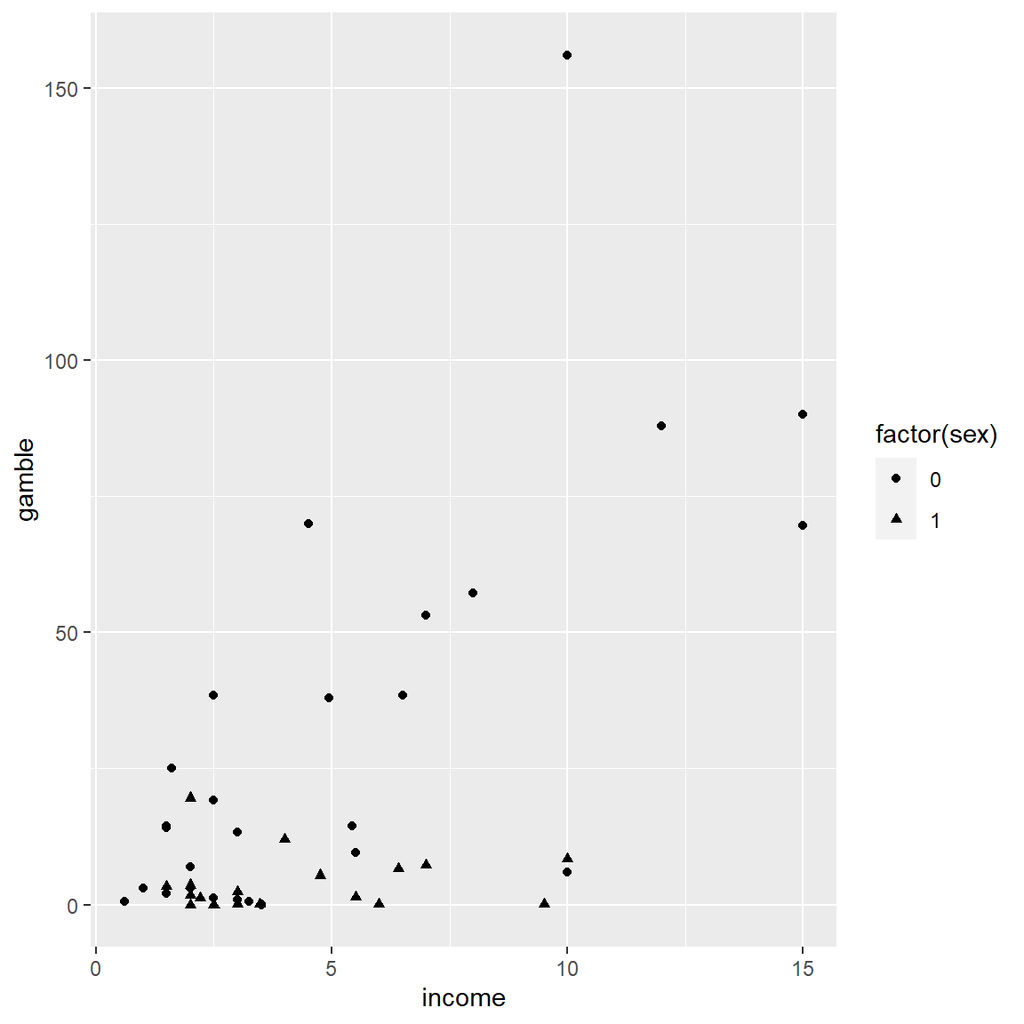

```r
#The easiest way to get ggplot2 is to install the whole tidyverse:
#install.packages("tidyverse")
library(tidyverse)
ggplot(data=teengamb, aes(x=income, y=gamble)) + geom_point(aes(shape=factor(sex)))
```

**Put your answer, explanation, findings here**

### (b) Fit a regression model with gamble as the response and income and sex as predictors. Display the regression fit on the plot.

Your code:

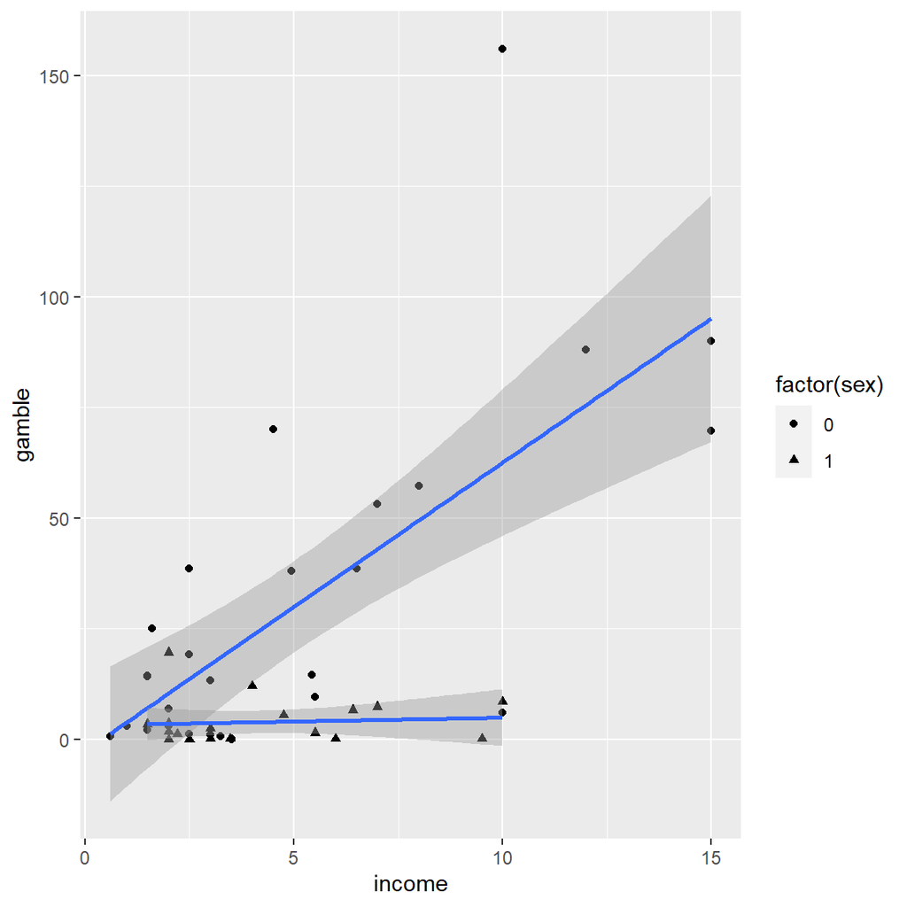

```r
ggplot(data=teengamb, aes(x=income, y=gamble)) + geom_point(aes(shape=factor(sex))) + geom_smooth(aes(group=factor(sex)), method='lm')
```

**Put your answer, explanation, findings here**

# Chapter 5 Problem 4:

### Thirty-nine MBA students were asked about happiness and how this related to their income and social life. The data are found in happy.(a) Fit a regression model with happy as the response and the other four variables as predictors. Give an interpretation for the meaning of the love coefficient.

Your code:

```r
data("happy", package="faraway")
summary(happy)
```

```
##      happy            money             sex              love
##  Min.   : 2.000   Min.   :  0.00   Min.   :0.0000   Min.   :1.000
##  1st Qu.: 5.000   1st Qu.: 42.50   1st Qu.:0.0000   1st Qu.:2.000
##  Median : 7.000   Median : 50.00   Median :1.0000   Median :3.000
##  Mean   : 6.744   Mean   : 62.15   Mean   :0.6923   Mean   :2.462
##  3rd Qu.: 8.000   3rd Qu.: 78.00   3rd Qu.:1.0000   3rd Qu.:3.000
##  Max.   :10.000   Max.   :175.00   Max.   :1.0000   Max.   :3.000
##       work
##  Min.   :1.000
##  1st Qu.:3.000
##  Median :4.000
##  Mean   :3.359
##  3rd Qu.:4.000
##  Max.   :5.000
```

```r
lmod <- lm(happy ~ money + sex + love + work, data=happy)
summary(lmod)
```

```
##
## Call:
## lm(formula = happy ~ money + sex + love + work, data = happy)
##
## Residuals:
##     Min      1Q  Median      3Q     Max
## -2.7186 -0.5779 -0.1172  0.6340  2.0651
##
## Coefficients:
##              Estimate Std. Error t value Pr(>|t|)
## (Intercept) -0.072081   0.852543  -0.085   0.9331
## money        0.009578   0.005213   1.837   0.0749 .
## sex         -0.149008   0.418525  -0.356   0.7240
## love         1.919279   0.295451   6.496 1.97e-07 ***
## work         0.476079   0.199389   2.388   0.0227 *
## ---
## Signif. codes:  0 '***' 0.001 '**' 0.01 '*' 0.05 '.' 0.1 ' ' 1
##
## Residual standard error: 1.058 on 34 degrees of freedom
## Multiple R-squared:  0.7102, Adjusted R-squared:  0.6761
## F-statistic: 20.83 on 4 and 34 DF,  p-value: 9.364e-09
```

Your answer: When love goes up by 1, then happiness will increase by 1.919279 because that is the value of coefficient for love.

**Put your answer, explanation, findings here**

### (b) The love predictor takes three possible values but mostly takes the value 2 or 3. Create a new predictor called clove which takes the value zero if love is 2 or less. Use this new predictor to replace love in the regression model and interpret the meaning of the corresponding coefficient. Do the results differ much from the previous model?

Your code:

```r
happy <- happy %>%
  mutate(clove=ifelse(love <= 2, 0, 1))
happy
```

```
##    happy money sex love work clove
## 1     10    36   0    3    4     1
## 2      8    47   1    3    1     1
## 3      8    53   0    3    5     1
## 4      8    35   1    3    3     1
## 5      4    88   1    1    2     0
## 6      9   175   1    3    4     1
## 7      8   175   1    3    4     1
## 8      6    45   0    2    3     0
## 9      5    35   1    2    2     0
## 10     4    55   1    1    4     0
## 11     7    40   0    2    3     0
## 12     8    45   1    3    4     1
## 13     8    45   1    3    3     1
## 14     8    45   1    3    4     1
```

[output cut: 25 more lines]

```r
lmod_clove <- lm(happy ~ money + sex + clove + work, data=happy)
summary(lmod_clove)
```

```
##
## Call:
## lm(formula = happy ~ money + sex + clove + work, data = happy)
##
## Residuals:
##     Min      1Q  Median      3Q     Max
## -2.5423 -0.8452 -0.1656  0.6546  2.1307
##
## Coefficients:
##              Estimate Std. Error t value Pr(>|t|)
## (Intercept)  3.453999   0.840018   4.112 0.000235 ***
## money        0.007290   0.005675   1.285 0.207638
## sex         -0.329123   0.460664  -0.714 0.479824
## clove        2.296435   0.411731   5.578 3.05e-06 ***
## work         0.544159   0.213535   2.548 0.015511 *
## ---
## Signif. codes:  0 '***' 0.001 '**' 0.01 '*' 0.05 '.' 0.1 ' ' 1
##
## Residual standard error: 1.145 on 34 degrees of freedom
## Multiple R-squared:  0.6609, Adjusted R-squared:  0.621
## F-statistic: 16.56 on 4 and 34 DF,  p-value: 1.27e-07
```

Your answer: When clove goes up by 1, then happiness will increase by 2.296435 because that is the value of coefficient for clove. The results differ a little bit because in the previous problem the coefficient for love was 1.919279, but now the coefficient for clove is 2.296435 which is a little bit bigger.

**Put your answer, explanation, findings here**

## (c) Fit a model with only clove as a predictor and interpret the coefficient. How do the results compare to the previous outcome.

Your code:

```r
lmod_clove_only <- lm(happy ~ clove, data=happy)
summary(lmod_clove_only)
```

```
##
## Call:
## lm(formula = happy ~ clove, data = happy)
##
## Residuals:
##     Min      1Q  Median      3Q     Max
## -3.2778 -0.6389  0.0000  0.8611  2.7222
##
## Coefficients:
##             Estimate Std. Error t value Pr(>|t|)
## (Intercept)   5.2778     0.2992  17.641  < 2e-16 ***
## clove         2.7222     0.4077   6.677 7.67e-08 ***
## ---
## Signif. codes:  0 '***' 0.001 '**' 0.01 '*' 0.05 '.' 0.1 ' ' 1
##
## Residual standard error: 1.269 on 37 degrees of freedom
## Multiple R-squared:  0.5465, Adjusted R-squared:  0.5342
## F-statistic: 44.58 on 1 and 37 DF,  p-value: 7.667e-08
```

Your answer: When clove goes up by 1 in this model, then happiness will increase by 2.7222 because that is the value of coefficient for clove in this model. The results differ a little bit because in an earlier problem the coefficient for love was 1.919279, and then the coefficient for clove was 2.296435 which was a little bit bigger. But now this coefficient for clove is even bigger.

**Put your answer, explanation, findings here**